# Lab B0: Reproducible reports and version control

STA 198 Summer 2020 (Jiang)

Today’s lab will introduce the computing tools we will be using this semester and the workflow for all assignments in this course. You will learn how to clone a remote repository from GitHub into an RStudio Cloud project, create a reproducible visualization and report using R Markdown, and push your changes to your own GitHub repository. Finally, although you will knit your finished report into a .pdf file and submit it to Gradescope, **this week’s lab will not be graded for credit.**

That was a lot of new vocab – let’s explore what some of these things are!

# Meet the toolkit

**R** is a free, open-source statistical programming language used for computation, data analysis, and graphics generation. It is widely used by statisticians, data scientists, and applied researchers in many fields. R is flexible and freely available to the public, who have in turn written many user-contributed **packages** which provide additional functionality.

**RStudio** is a free and convenient interface for R (technically an **integrated development environment**, or IDE) that adds convenient features and tools, such as for developing packages or exporting output in convenient formats. In this class, we’ll be doing all of our computation in RStudio. At its simplest, R is like a car’s engine, and RStudio is akin to its dashboard (credit to Chester Ismay and Albert Kim at [Modern Dive](https://moderndive.com/) for the analogy).

RStudio has a number of built-in tools and extensions. For instance, we can use *literate programming* (that is, having code, narrative, and output all in one document) using **R Markdown**, which is natively supported by RStudio. R Markdown allows the creation of fully reproducible reports – the analysis is run from the beginning each time you **knit** the document. Depending on your personal set-up, you can knit to .pdf documents, .html documents, or other formats. In fact, this lab webpage was written in R Markdown.

**Git** is a free, open-source version control system (kind of like track changes from word, but way more robust) that can also be used for collaboration among multiple contributors. Users can **commit** to a repository that contains any number of files, and the complete commit history is authenticated, cryptographically secure, and shareable. **GitHub** is a free and widely-used online hosting service for collaboration and version control using Git and is the home of the Git-based projects on the internet in this course.

**RStudio Cloud** is an online, cloud-hosted service that runs a distributed instance of RStudio. Anyone with an RStudio Cloud account and internet access can use this RStudio Cloud to run RStudio directly in a web browser, *without* installing anything on their own computer. Importantly, it interfaces well with GitHub (as we will see today), and already has everything built-in to allow you to directly knit well-formatted .pdf and .html documents without installation of additional dependencies.

# The basic workflow

Each assignment in this course will follow the same basic workflow. It may seem daunting at first, but before too long it will become second nature. The steps are as follows; in subsequent sections of this document, we’ll walk through them together in more detail (refer to the recording if you need any help, or ask your lab TA).

- Clone an existing assignment repository into a personal repository.
- Create a new RStudio Cloud Project based on your cloned repository.
- Perform your data analysis in RStudio Cloud in an R Markdown document (staging, committing, and pushing changes to your repository as necessary).
- Knit your final product into a .pdf document, and push one final time to your repository.
- Upload this .pdf document to Gradescope.

# Creating our first visualization

## Preliminary steps

First, make sure that you are part of both the GitHub organization for the class. The course GitHub organization already has every assignment in a private repository. In STA 198, we’ve made it easy to clone a repository to a personal GitHub repository accessible only to you, the instructor/TAs, and any potential group members.

First, make sure that you are a member of the course organization GitHub repository at https://github.com/sta198-su20. You should see a screenshot similar to the following, inviting you to join this organization:

[figure not shown]

Upon clicking the link at the top of the page, you should see the following screen:

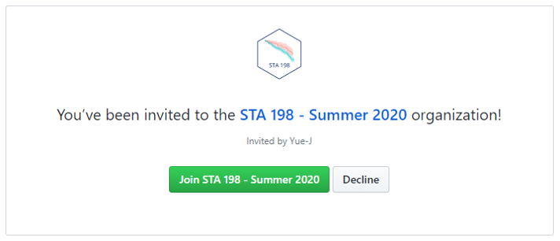

Join the organization by clicking on the green button.

As well, make sure you are a member of the RStudio Cloud organization. You should have received an e-mail inviting you to join an RStudio Cloud workspace.

## Clone an existing repository

To clone the Lab B0 directory into your own private repository, click on the following link: https://classroom.github.com/a/1o-E2RXo. You should see a screenshot as follows:

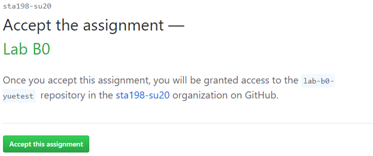

When all done, you should see the following screen, letting you know that the repository creation was successful:

[figure not shown]

Clicking on this link will bring you to your private repository. On the right side, you will see a green button which will give you a .git link to use to clone the repository:

[figure not shown]

## Create an RStudio Cloud project

Next, go to the course workspace https://rstudio.cloud/spaces/68881/ and login using your GitHub credentials. You should see a screen similar to the following (note that you may have to sign into GitHub to continue to RStudio Cloud):

[figure not shown]

Once you are in this workspace, create a new project from Git Repo using the button in the top-right hand corner:

[figure not shown]

You will be prompted to enter in a Git link from which to clone the project. Use the link from the repository that you created before:

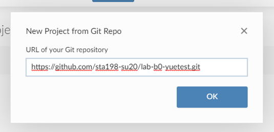

You will be prompted once again to enter in your GitHub login credentials. Make sure you do this accurately (if you don’t, the clone won’t work):

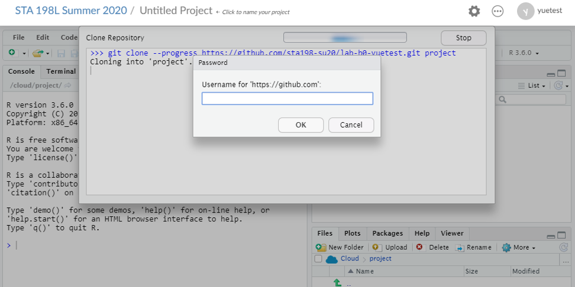

## Perform the data analysis

You should now see the RStudio Cloud workspace. Click on the document `lab-b0.Rmd` to bring up the R Markdown file associated with the lab. As well, rename the project in the top of the screen to something informative (here, I’ve used “Lab B0” as the title). You should see a screen similar to the following:

[figure not shown]

R Markdown is a system that may be used to create easy-to-write, attractive reports, presentations, or webpages that also serve as reproducible records of the data analysis. These reports have the desirable property of being able to not only display written text narratives and figures, but also include any R code and the outputs from these code snippets and analyses.

Every assignment lab in this class will be written in R Markdown, with a template provided for you to use. Here, we’ve opened the template `lab-b0.Rmd`. Fill in answers in the spaces provided: text narrative should be typed directly in the document and any included R code should be typed inside “chunks,” or sections defined by three backticks (the little mark on the same key as the tilde).

Let’s explore some of the windows you see open in RStudio. The **console** is the panel on the bottom-left, and is where users can type commands and see immediate output. Let’s try it out! Type the following code into the console:

```r
3+4
```

You should get output that looks like

```
## [1] 7
```

(For now, ignore the `[1]`). By typing in `3+4`, we got the expected answer, `7`. We can see that R can be used as a calculator directly in the console. Try some other commands that use R as a calculator. For instance, `4*25`, `exp(1.5)`, or `(12+5^3)/sqrt(70)`. Of course, R is not simply a calculator; other commands may also be entered here.

**An important thing to note** is that the environment of the R Markdown document is completely separate from the console. For instance, if you load in a package in the console in order to run some analyses, if you use the R Markdown document to create a report, you will not be able to use those functions unless you also load the packages into the R Markdown environment. Similarly, if you load some data into the console, you will not be able to access it in the “knitting environment” unless you load it into a code chunk (see recording for further explanation).

In the R chunk for Exercise 1 (it should be shaded in gray), copy/paste the following code exactly as it appears here, and then click on the green “playbutton” in the R chunk. We are creating a visualization that tracks the cumulative cases of COVID-19 across four countries (on the log-10 scale); this code was adapted from Duke’s very own Dr. Kieran Healy using data from the ECDC that I’ve cleaned and simplified for the purposes of this example. Don’t worry about what the code does for now, but in just a few short weeks you’ll understand all of it!

```r
library(tidyverse)

covid_cases <- read_csv("data/covid_cases.csv")

covid_cases_bg <- covid_cases %>%
  select(-cname)

cnames <- covid_cases %>%
  select(cname) %>%
  unique()

ex_plot <- covid_cases  %>%
  ggplot(mapping = aes(x = as.numeric(days_elapsed), y = cu_cases)) +
  geom_line(data = covid_cases_bg,
            aes(group = iso3),
            size = 0.15, color = "darkgrey") +
  geom_line(color = "firebrick",
            lineend = "round") +
  scale_y_log10(labels = scales::label_number_si()) +
  facet_wrap(~ cname, ncol = 2) +
  labs(x = "Days Since 100th Confirmed Case",
       y = "Cumulative Reported Cases (log10 scale)",
       title = "Cumulative Reported Cases of COVID-19",
       subtitle = "Followed for 2 months after 100th confirmed case",
        caption = "Adapted from code by Kieran Healy; Data from https://www.ecdc.europa.eu/") +
  theme_bw() +
  theme(plot.title = element_text(face = "bold"))

ex_plot
```

We’ve loaded and created a few datasets into the Console **environment** and created a plot (you’ll see a squished preview under the R chunk. These datasets and other objects are now part of our environment, which is displayed on the top half of the right side of the RStudio window.

The environment contains all objects in the current working space. These objects could be variables, lists of variables, or even entire datasets. In the same location as the environment tab, the **history** tab displays all commands used during the current session (don’t worry about the connections tab for now). Finally, the bottom half of the right-hand panel shows information regarding files on your hard drive, installed packages, output such as plots, and help files or other documents.

## Knit a report

Keep in mind that the Console environment and the knitting environment are different. In order to turn this template into a shareable document, **knit** the R Markdown document into a .pdf document by pressing the Knit button in the taskbar (appropriately, it has a ball of yarn next to it). You may have to click on the arrow next to the button to select .pdf document. Once you do so, you should see your .Rmd document rendered as a .pdf file!

Take a moment now to answer Exercise 2 – replace the sentence in the template with one describing the figure you created, and re-knit the document. While you’re at it, save changes to the RStudio Cloud project (just Control + S or Command + S).

## Configuring GitHub

Next, we need to configure RStudio Cloud and GitHub such that they can communicate with each other. Type the following lines of code in the console in RStudio filling in your name and email address (replacing the `user.name` and `user.email` arguments as necessary):

```r
library(usethis)
use_git_config(user.name = "your name", user.email = "your email")
```

Your email address is the address tied to your GitHub account and your name should be first and last name. For instance, mine would be

```r
library(usethis)
use_git_config(user.name = "Yue Jiang", user.email = "yue.jiang@duke.edu")
```

## Push changes to GitHub

We’ve made a number of changes. How can we keep track of version control and make those changes reflected in the repository we created earlier? We will have to **push** them to GitHub.

In RStudio Cloud, the top-right window has a tab that contains the Git window:

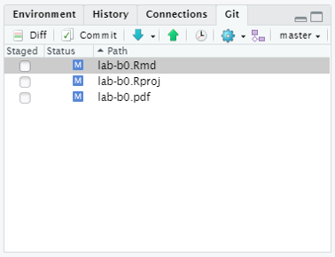

We see a list of documents that we’ve changed. To prepare these changes for the eventual pushing process, we’ll first **stage** them by checking the boxes next to the documents whose changes we want to keep (in this case, all of them):

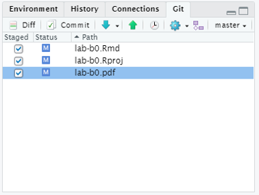

Next, we will **commit** those changes to the local repository (don’t worry about the details for now, just know that we are formally committing those changes “somewhere”). To do this, click on the Commit button in the bar, making sure that all documents whose changes you want to commit are properly staged. This should open up a commit window that looks like the following:

[figure not shown]

Write an informative commit message (e.g., “Created visualization”) in the top- right box, and click on the Commit button.

If everything works, then you should see a window pop-up with the committed changes. In this case we have:

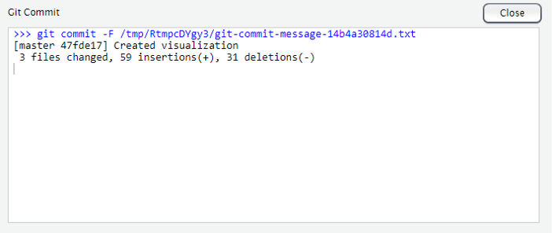

You should now see that there are no more changes to commit to the local repository (this is the “somewhere”). The last step is to **push** these committed changes to the remote repository – the one you created on GitHub earlier. You will see a message that you are “ahead of the master” by one commit. The “master” branch is what lives on the remote repository. Click on the Push button in the top-right corner of the Commit window in order to push these local changes to the remote repository. You will have to log-in to GitHub again:

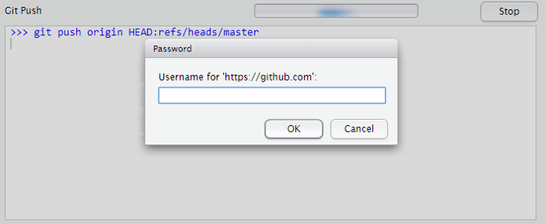

If everything is done successfully, the master branch will now be current with your changes:

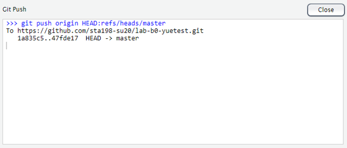

Going back to the master branch in the GitHub repository, we can see our changes:

[figure not shown]

# Uploading report to Gradescope

The R Markdown document we modified earlier was used to create a .pdf report. This report can be downloaded from your GitHub repository (or, if you still have the window open, you can just download it from there). Note that you *must* turn in a .pdf file corresponding to the R Markdown template to Gradescope in order to receive credit for assignments.

To do so, simply go to Gradescope and upload your knitted .pdf document. You will see a window asking you to “associate” exercises with certain pages. **Be sure to accurately do so, otherwise the graders may not be able to see your work.**

Phew! That concludes this process – it’s an ordeal, I know. Like I said, in just a few weeks, this entire workflow will come naturally to you. If you need a refresher, refer back to the recording on Sakai and this document.